# Sara_data_box_whisker

Nicole

3/4/2022

# Helpful Tips

**Useful keyboard shortcuts** *these work for windows, they may be different for Macs*

- `Cntrl` + `Z` functions like the Undo button in word or excel. Undoes whatever action you just did
- `Cntrl` + `Alt` + `I` inserts a new code chunk
- `Cntrl` + `Enter` runs the code that your courser is on (good for if you want to run small sections of code within a larger code chunk)
- `Cntrl` + `Shift` + `M` inserts the pipe functions `%>%`
- `Cntrl` + `F` allows you to find things within the document (can be useful if you want to replace the name of an object everywhere in the document at the same time)
- `Cntrl` + `Shift` + `O` opens a document outline that you can use to quickly navigate between titled sections of your document
- `Cntrl` + `C` to copy, `Cntrl` + `V` to paste
- `Cntrl` + `S` to save

Use `rm(list = ls())` to Clear workspace (if desired/needed). If run correctly will clear everything from your environment tab. Typically it’s good to do this at the start of each of your sessions. Defiantly should do it if you open a new Rmd file.

Use this`getwd()` to check working directory. Will most likely be whatever folder your Rmd file is in. If you need to change it for some reason use `setwd()`

# Downloading/loading packages

Use `install.packages` to download and install a new R package. You only need to do this once, then you can just use `library()` to load it and be able to call functions within it. and load the package libraries.

**TIP: It’s generally considered best practice to keep the commands to call all the packages you need to use at the top of the document**

`tidyr`, `dplyr`, and `readr` are probably the most commonly used packages for data wrangling/cleaning.`ggplot2` is very common for creating publication quality figures.

**Note: The order which you install packages is important. Functions with the same names will be masked by packages loaded in after the previous.**  
Ex: The `select()` function from `MASS` will be masked by `select()` from `dplyar`

```r
library("tidyr")
library("dplyr")
library("readr")
library("ggplot2")
library("ggpubr")
```

# Data Wrangling

Read in your data

```r
data_orig <- read.csv("../Data/sara_raw_data.csv")
```

Look at the data to see what it contains  
*Make sure the column names in each data set match so they can be merged together*

```r
head(data_orig) #opens first 6 rows
tail(data_orig) #opens last 6 rows
summary(data_orig)
str(data_orig) #tells us what data types (numbers, factors, etc) are in the data frame
```

### Remove any data that you will not need for the analysis

Check unique values

```r
unique(data_orig$Site)
```

```
##  [1] "Bens Run"                 "Control"
##  [3] "Covered Bridge"           "Dead Run"
##  [5] "East Beaverdam"           "Goodwin Run"
##  [7] "Gwynn Falls Chartly"      "Kelly Branch"
##  [9] "Minebank "                "Moores Branch"
## [11] "Scotts Level McDonogh"    "Scotts Level Park"
## [13] "Towson Run"               "Tributary to Gwynn Falls"
## [15] "Wellwood"
```

drop the controls

```r
data_orig <- data_orig %>% filter(Site != "Control")
```

```r
data_sum_by_plot <- (data_orig) %>%
  group_by(Site, Mat.Number) %>%
  summarise(sumBYmat = sum(Sum.of.total.germinants.by.pot.), n = n())
rst <- (data_sum_by_plot) %>%
  filter(Site == "Dead Run" | Site== "East Beaverdam" | Site == "Gwynn Falls Chartly" | Site == "Kelly Branch" | Site == "Scotts Level McDonogh" | Site =="Towson Run" | Site == "Wellwood")

urst <- (data_sum_by_plot) %>%
  filter(Site == "Bens Run" | Site== "Covered Bridge" | Site == "Goodwin Run" | Site == "Minebank " | Site == "Moores Branch" | Site =="Scotts Level Park" | Site == "Tributary to Gwynn Falls")

#unique(urst$Site)

#create vectors
rest <- c("restored")
unrest <- c("unrestored")

#assign staus in new column
rst["status"] <-rest
urst["status"] <-unrest


MyMerge       <- function(x, y){
  df            <- merge(x, y, all = TRUE)
  rownames(df)  <- df$Row.names
  df$Row.names  <- NULL
  return(df)
}
status_sum_by_plot           <- Reduce(MyMerge, list(rst, urst))
```

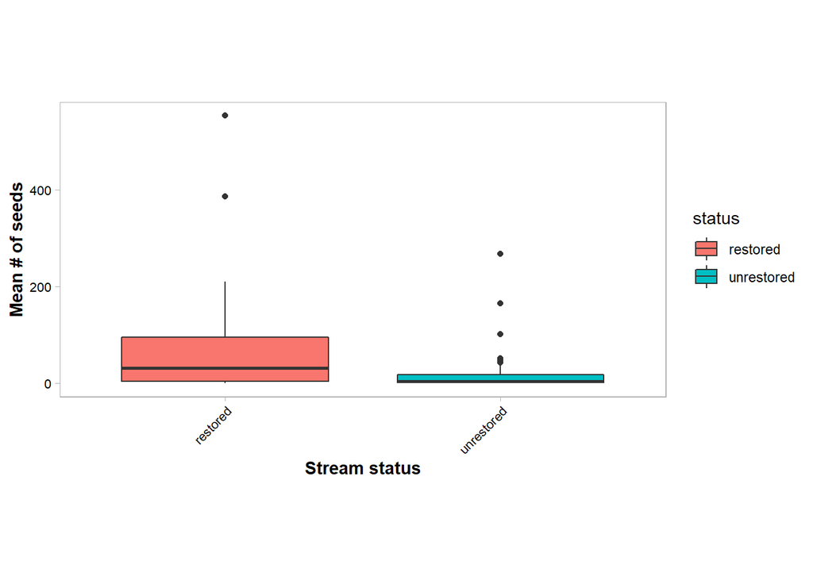

```r
  BoxPlotall <- ggplot(status_sum_by_plot, aes(x= status, y=sumBYmat, fill = status))+
      geom_boxplot(position=position_dodge(.85))+
     theme_light()+
     theme(panel.grid.major = element_blank(), panel.grid.minor = element_blank())+
     theme(axis.title.y = element_text(face = "bold"))+
     theme(axis.title.x = element_text(face = "bold"))+
     theme(plot.title = element_text(hjust = .5))+
     theme(axis.text.x = element_text(color = "black", size = 8, angle = 45, hjust = 1))+
     theme(axis.text.y = element_text(color = "black", size = 8))+
     theme(aspect.ratio = 9/18.5)+
  labs(y = "Mean # of seeds", x = "Stream status")

print(BoxPlotall)
```

```r
#ggsave("Figures/Sara_BOXPLOT.jpeg")
```